# Risk Factor Analysis

## Outcome Variable

**Outcome Variable:** ever_wasted

## Predictor Variables

**Intervention Variable:** born_wasted

**Adjustment Set:**

- arm
- sex
- W_mage
- meducyrs
- feducyrs
- hhwealth_quart
- vagbrth
- W_nrooms
- month
- brthmon
- W_parity
- impfloor
- impsan
- delta_W_mage
- delta_meducyrs
- delta_feducyrs
- delta_hhwealth_quart
- delta_vagbrth
- delta_W_nrooms
- delta_month
- delta_brthmon
- delta_W_parity
- delta_impfloor
- delta_impsan

## Stratifying Variables

The analysis was stratified on these variable(s):

- agecat
- studyid
- country

## Data Summary

| agecat | studyid | country | born_wasted | ever_wasted | n_cell | n |
| --- | --- | --- | --- | --- | --- | --- |
| 0-3 months | ki0047075b-MAL-ED | BANGLADESH | 0 | 0 | 195 | 244 |
| 0-3 months | ki0047075b-MAL-ED | BANGLADESH | 0 | 1 | 9 | 244 |
| 0-3 months | ki0047075b-MAL-ED | BANGLADESH | 1 | 0 | 40 | 244 |
| 0-3 months | ki0047075b-MAL-ED | BANGLADESH | 1 | 1 | 0 | 244 |
| 0-3 months | ki0047075b-MAL-ED | BRAZIL | 0 | 0 | 171 | 183 |
| 0-3 months | ki0047075b-MAL-ED | BRAZIL | 0 | 1 | 6 | 183 |
| 0-3 months | ki0047075b-MAL-ED | BRAZIL | 1 | 0 | 6 | 183 |
| 0-3 months | ki0047075b-MAL-ED | BRAZIL | 1 | 1 | 0 | 183 |
| 0-3 months | ki0047075b-MAL-ED | INDIA | 0 | 0 | 149 | 204 |
| 0-3 months | ki0047075b-MAL-ED | INDIA | 0 | 1 | 21 | 204 |
| 0-3 months | ki0047075b-MAL-ED | INDIA | 1 | 0 | 34 | 204 |
| 0-3 months | ki0047075b-MAL-ED | INDIA | 1 | 1 | 0 | 204 |
| 0-3 months | ki0047075b-MAL-ED | NEPAL | 0 | 0 | 143 | 168 |
| 0-3 months | ki0047075b-MAL-ED | NEPAL | 0 | 1 | 5 | 168 |
| 0-3 months | ki0047075b-MAL-ED | NEPAL | 1 | 0 | 20 | 168 |
| 0-3 months | ki0047075b-MAL-ED | NEPAL | 1 | 1 | 0 | 168 |
| 0-3 months | ki0047075b-MAL-ED | PERU | 0 | 0 | 274 | 282 |
| 0-3 months | ki0047075b-MAL-ED | PERU | 0 | 1 | 2 | 282 |
| 0-3 months | ki0047075b-MAL-ED | PERU | 1 | 0 | 6 | 282 |
| 0-3 months | ki0047075b-MAL-ED | PERU | 1 | 1 | 0 | 282 |
| 0-3 months | ki0047075b-MAL-ED | SOUTH AFRICA | 0 | 0 | 234 | 258 |
| 0-3 months | ki0047075b-MAL-ED | SOUTH AFRICA | 0 | 1 | 6 | 258 |
| 0-3 months | ki0047075b-MAL-ED | SOUTH AFRICA | 1 | 0 | 18 | 258 |
| 0-3 months | ki0047075b-MAL-ED | SOUTH AFRICA | 1 | 1 | 0 | 258 |
| 0-3 months | ki0047075b-MAL-ED | TANZANIA, UNITED REPUBLIC OF | 0 | 0 | 142 | 145 |
| 0-3 months | ki0047075b-MAL-ED | TANZANIA, UNITED REPUBLIC OF | 0 | 1 | 1 | 145 |
| 0-3 months | ki0047075b-MAL-ED | TANZANIA, UNITED REPUBLIC OF | 1 | 0 | 2 | 145 |
| 0-3 months | ki0047075b-MAL-ED | TANZANIA, UNITED REPUBLIC OF | 1 | 1 | 0 | 145 |
| 0-3 months | ki1000108-CMC-V-BCS-2002 | INDIA | 0 | 0 | 42 | 88 |
| 0-3 months | ki1000108-CMC-V-BCS-2002 | INDIA | 0 | 1 | 32 | 88 |

[output cut: 410 more lines]

The following strata were considered:

- agecat: 0-3 months, studyid: ki0047075b-MAL-ED, country: BANGLADESH
- agecat: 0-3 months, studyid: ki0047075b-MAL-ED, country: BRAZIL
- agecat: 0-3 months, studyid: ki0047075b-MAL-ED, country: INDIA
- agecat: 0-3 months, studyid: ki0047075b-MAL-ED, country: NEPAL
- agecat: 0-3 months, studyid: ki0047075b-MAL-ED, country: PERU
- agecat: 0-3 months, studyid: ki0047075b-MAL-ED, country: SOUTH AFRICA
- agecat: 0-3 months, studyid: ki0047075b-MAL-ED, country: TANZANIA, UNITED REPUBLIC OF
- agecat: 0-3 months, studyid: ki1000108-CMC-V-BCS-2002, country: INDIA
- agecat: 0-3 months, studyid: ki1000108-IRC, country: INDIA
- agecat: 0-3 months, studyid: ki1000109-EE, country: PAKISTAN
- agecat: 0-3 months, studyid: ki1000109-ResPak, country: PAKISTAN
- agecat: 0-3 months, studyid: ki1000304b-SAS-CompFeed, country: INDIA
- agecat: 0-3 months, studyid: ki1017093-NIH-Birth, country: BANGLADESH
- agecat: 0-3 months, studyid: ki1017093b-PROVIDE, country: BANGLADESH
- agecat: 0-3 months, studyid: ki1017093c-NIH-Crypto, country: BANGLADESH
- agecat: 0-3 months, studyid: ki1101329-Keneba, country: GAMBIA
- agecat: 0-3 months, studyid: ki1114097-CMIN, country: BANGLADESH
- agecat: 0-3 months, studyid: ki1114097-CMIN, country: BRAZIL
- agecat: 0-3 months, studyid: ki1114097-CMIN, country: GUINEA-BISSAU
- agecat: 0-3 months, studyid: ki1114097-CMIN, country: PERU
- agecat: 0-3 months, studyid: ki1114097-CONTENT, country: PERU
- agecat: 0-3 months, studyid: ki1119695-PROBIT, country: BELARUS
- agecat: 0-3 months, studyid: ki1126311-ZVITAMBO, country: ZIMBABWE
- agecat: 0-3 months, studyid: ki1135781-COHORTS, country: GUATEMALA
- agecat: 0-3 months, studyid: ki1135781-COHORTS, country: INDIA
- agecat: 0-3 months, studyid: ki1135781-COHORTS, country: PHILIPPINES
- agecat: 0-3 months, studyid: kiGH5241-JiVitA-3, country: BANGLADESH
- agecat: 0-3 months, studyid: kiGH5241-JiVitA-4, country: BANGLADESH
- agecat: 12-24 months, studyid: ki0047075b-MAL-ED, country: BANGLADESH
- agecat: 12-24 months, studyid: ki0047075b-MAL-ED, country: BRAZIL
- agecat: 12-24 months, studyid: ki0047075b-MAL-ED, country: INDIA
- agecat: 12-24 months, studyid: ki0047075b-MAL-ED, country: NEPAL
- agecat: 12-24 months, studyid: ki0047075b-MAL-ED, country: PERU
- agecat: 12-24 months, studyid: ki0047075b-MAL-ED, country: SOUTH AFRICA
- agecat: 12-24 months, studyid: ki0047075b-MAL-ED, country: TANZANIA, UNITED REPUBLIC OF
- agecat: 12-24 months, studyid: ki1000108-CMC-V-BCS-2002, country: INDIA
- agecat: 12-24 months, studyid: ki1000108-IRC, country: INDIA
- agecat: 12-24 months, studyid: ki1000109-EE, country: PAKISTAN
- agecat: 12-24 months, studyid: ki1000109-ResPak, country: PAKISTAN
- agecat: 12-24 months, studyid: ki1000304b-SAS-CompFeed, country: INDIA
- agecat: 12-24 months, studyid: ki1017093-NIH-Birth, country: BANGLADESH
- agecat: 12-24 months, studyid: ki1017093b-PROVIDE, country: BANGLADESH
- agecat: 12-24 months, studyid: ki1017093c-NIH-Crypto, country: BANGLADESH
- agecat: 12-24 months, studyid: ki1101329-Keneba, country: GAMBIA
- agecat: 12-24 months, studyid: ki1114097-CMIN, country: BANGLADESH
- agecat: 12-24 months, studyid: ki1114097-CMIN, country: BRAZIL
- agecat: 12-24 months, studyid: ki1114097-CMIN, country: GUINEA-BISSAU
- agecat: 12-24 months, studyid: ki1114097-CMIN, country: PERU
- agecat: 12-24 months, studyid: ki1114097-CONTENT, country: PERU
- agecat: 12-24 months, studyid: ki1119695-PROBIT, country: BELARUS
- agecat: 12-24 months, studyid: ki1126311-ZVITAMBO, country: ZIMBABWE
- agecat: 12-24 months, studyid: ki1135781-COHORTS, country: GUATEMALA
- agecat: 12-24 months, studyid: ki1135781-COHORTS, country: PHILIPPINES
- agecat: 12-24 months, studyid: kiGH5241-JiVitA-3, country: BANGLADESH
- agecat: 12-24 months, studyid: kiGH5241-JiVitA-4, country: BANGLADESH
- agecat: 3-6 months, studyid: ki0047075b-MAL-ED, country: BANGLADESH
- agecat: 3-6 months, studyid: ki0047075b-MAL-ED, country: BRAZIL
- agecat: 3-6 months, studyid: ki0047075b-MAL-ED, country: INDIA
- agecat: 3-6 months, studyid: ki0047075b-MAL-ED, country: NEPAL
- agecat: 3-6 months, studyid: ki0047075b-MAL-ED, country: PERU
- agecat: 3-6 months, studyid: ki0047075b-MAL-ED, country: SOUTH AFRICA
- agecat: 3-6 months, studyid: ki0047075b-MAL-ED, country: TANZANIA, UNITED REPUBLIC OF
- agecat: 3-6 months, studyid: ki1000108-CMC-V-BCS-2002, country: INDIA
- agecat: 3-6 months, studyid: ki1000108-IRC, country: INDIA
- agecat: 3-6 months, studyid: ki1000109-EE, country: PAKISTAN
- agecat: 3-6 months, studyid: ki1000109-ResPak, country: PAKISTAN
- agecat: 3-6 months, studyid: ki1000304b-SAS-CompFeed, country: INDIA
- agecat: 3-6 months, studyid: ki1017093-NIH-Birth, country: BANGLADESH
- agecat: 3-6 months, studyid: ki1017093b-PROVIDE, country: BANGLADESH
- agecat: 3-6 months, studyid: ki1017093c-NIH-Crypto, country: BANGLADESH
- agecat: 3-6 months, studyid: ki1101329-Keneba, country: GAMBIA
- agecat: 3-6 months, studyid: ki1114097-CMIN, country: BANGLADESH
- agecat: 3-6 months, studyid: ki1114097-CMIN, country: BRAZIL
- agecat: 3-6 months, studyid: ki1114097-CMIN, country: GUINEA-BISSAU
- agecat: 3-6 months, studyid: ki1114097-CMIN, country: PERU
- agecat: 3-6 months, studyid: ki1114097-CONTENT, country: PERU
- agecat: 3-6 months, studyid: ki1119695-PROBIT, country: BELARUS
- agecat: 3-6 months, studyid: ki1126311-ZVITAMBO, country: ZIMBABWE
- agecat: 3-6 months, studyid: ki1135781-COHORTS, country: GUATEMALA
- agecat: 3-6 months, studyid: ki1135781-COHORTS, country: PHILIPPINES
- agecat: 3-6 months, studyid: kiGH5241-JiVitA-3, country: BANGLADESH
- agecat: 3-6 months, studyid: kiGH5241-JiVitA-4, country: BANGLADESH
- agecat: 6-12 months, studyid: ki0047075b-MAL-ED, country: BANGLADESH
- agecat: 6-12 months, studyid: ki0047075b-MAL-ED, country: BRAZIL
- agecat: 6-12 months, studyid: ki0047075b-MAL-ED, country: INDIA
- agecat: 6-12 months, studyid: ki0047075b-MAL-ED, country: NEPAL
- agecat: 6-12 months, studyid: ki0047075b-MAL-ED, country: PERU
- agecat: 6-12 months, studyid: ki0047075b-MAL-ED, country: SOUTH AFRICA
- agecat: 6-12 months, studyid: ki0047075b-MAL-ED, country: TANZANIA, UNITED REPUBLIC OF
- agecat: 6-12 months, studyid: ki1000108-CMC-V-BCS-2002, country: INDIA
- agecat: 6-12 months, studyid: ki1000108-IRC, country: INDIA
- agecat: 6-12 months, studyid: ki1000109-EE, country: PAKISTAN
- agecat: 6-12 months, studyid: ki1000109-ResPak, country: PAKISTAN
- agecat: 6-12 months, studyid: ki1000304b-SAS-CompFeed, country: INDIA
- agecat: 6-12 months, studyid: ki1017093-NIH-Birth, country: BANGLADESH
- agecat: 6-12 months, studyid: ki1017093b-PROVIDE, country: BANGLADESH
- agecat: 6-12 months, studyid: ki1017093c-NIH-Crypto, country: BANGLADESH
- agecat: 6-12 months, studyid: ki1101329-Keneba, country: GAMBIA
- agecat: 6-12 months, studyid: ki1114097-CMIN, country: BANGLADESH
- agecat: 6-12 months, studyid: ki1114097-CMIN, country: BRAZIL
- agecat: 6-12 months, studyid: ki1114097-CMIN, country: GUINEA-BISSAU
- agecat: 6-12 months, studyid: ki1114097-CMIN, country: PERU
- agecat: 6-12 months, studyid: ki1114097-CONTENT, country: PERU
- agecat: 6-12 months, studyid: ki1119695-PROBIT, country: BELARUS
- agecat: 6-12 months, studyid: ki1126311-ZVITAMBO, country: ZIMBABWE
- agecat: 6-12 months, studyid: ki1135781-COHORTS, country: GUATEMALA
- agecat: 6-12 months, studyid: ki1135781-COHORTS, country: INDIA
- agecat: 6-12 months, studyid: ki1135781-COHORTS, country: PHILIPPINES
- agecat: 6-12 months, studyid: kiGH5241-JiVitA-3, country: BANGLADESH
- agecat: 6-12 months, studyid: kiGH5241-JiVitA-4, country: BANGLADESH

### Dropped Strata

Some strata were dropped due to rare outcomes:

- agecat: 0-3 months, studyid: ki0047075b-MAL-ED, country: BANGLADESH
- agecat: 0-3 months, studyid: ki0047075b-MAL-ED, country: BRAZIL
- agecat: 0-3 months, studyid: ki0047075b-MAL-ED, country: INDIA
- agecat: 0-3 months, studyid: ki0047075b-MAL-ED, country: NEPAL
- agecat: 0-3 months, studyid: ki0047075b-MAL-ED, country: PERU
- agecat: 0-3 months, studyid: ki0047075b-MAL-ED, country: SOUTH AFRICA
- agecat: 0-3 months, studyid: ki0047075b-MAL-ED, country: TANZANIA, UNITED REPUBLIC OF
- agecat: 0-3 months, studyid: ki1000108-CMC-V-BCS-2002, country: INDIA
- agecat: 0-3 months, studyid: ki1000108-IRC, country: INDIA
- agecat: 0-3 months, studyid: ki1000109-EE, country: PAKISTAN
- agecat: 0-3 months, studyid: ki1000109-ResPak, country: PAKISTAN
- agecat: 0-3 months, studyid: ki1000304b-SAS-CompFeed, country: INDIA
- agecat: 0-3 months, studyid: ki1017093-NIH-Birth, country: BANGLADESH
- agecat: 0-3 months, studyid: ki1017093b-PROVIDE, country: BANGLADESH
- agecat: 0-3 months, studyid: ki1017093c-NIH-Crypto, country: BANGLADESH
- agecat: 0-3 months, studyid: ki1101329-Keneba, country: GAMBIA
- agecat: 0-3 months, studyid: ki1114097-CMIN, country: BANGLADESH
- agecat: 0-3 months, studyid: ki1114097-CMIN, country: BRAZIL
- agecat: 0-3 months, studyid: ki1114097-CMIN, country: GUINEA-BISSAU
- agecat: 0-3 months, studyid: ki1114097-CMIN, country: PERU
- agecat: 0-3 months, studyid: ki1114097-CONTENT, country: PERU
- agecat: 0-3 months, studyid: ki1119695-PROBIT, country: BELARUS
- agecat: 0-3 months, studyid: ki1126311-ZVITAMBO, country: ZIMBABWE
- agecat: 0-3 months, studyid: ki1135781-COHORTS, country: GUATEMALA
- agecat: 0-3 months, studyid: ki1135781-COHORTS, country: INDIA
- agecat: 0-3 months, studyid: ki1135781-COHORTS, country: PHILIPPINES
- agecat: 0-3 months, studyid: kiGH5241-JiVitA-3, country: BANGLADESH
- agecat: 0-3 months, studyid: kiGH5241-JiVitA-4, country: BANGLADESH
- agecat: 3-6 months, studyid: ki0047075b-MAL-ED, country: BANGLADESH
- agecat: 3-6 months, studyid: ki0047075b-MAL-ED, country: BRAZIL
- agecat: 3-6 months, studyid: ki0047075b-MAL-ED, country: INDIA
- agecat: 3-6 months, studyid: ki0047075b-MAL-ED, country: NEPAL
- agecat: 3-6 months, studyid: ki0047075b-MAL-ED, country: PERU
- agecat: 3-6 months, studyid: ki0047075b-MAL-ED, country: SOUTH AFRICA
- agecat: 3-6 months, studyid: ki0047075b-MAL-ED, country: TANZANIA, UNITED REPUBLIC OF
- agecat: 3-6 months, studyid: ki1000108-CMC-V-BCS-2002, country: INDIA
- agecat: 3-6 months, studyid: ki1000109-EE, country: PAKISTAN
- agecat: 3-6 months, studyid: ki1000109-ResPak, country: PAKISTAN
- agecat: 3-6 months, studyid: ki1017093-NIH-Birth, country: BANGLADESH
- agecat: 3-6 months, studyid: ki1017093b-PROVIDE, country: BANGLADESH
- agecat: 3-6 months, studyid: ki1017093c-NIH-Crypto, country: BANGLADESH
- agecat: 3-6 months, studyid: ki1114097-CMIN, country: BANGLADESH
- agecat: 3-6 months, studyid: ki1114097-CMIN, country: BRAZIL
- agecat: 3-6 months, studyid: ki1114097-CMIN, country: GUINEA-BISSAU
- agecat: 3-6 months, studyid: ki1114097-CMIN, country: PERU
- agecat: 3-6 months, studyid: ki1114097-CONTENT, country: PERU
- agecat: 3-6 months, studyid: ki1135781-COHORTS, country: GUATEMALA
- agecat: 3-6 months, studyid: kiGH5241-JiVitA-3, country: BANGLADESH
- agecat: 3-6 months, studyid: kiGH5241-JiVitA-4, country: BANGLADESH
- agecat: 6-12 months, studyid: ki0047075b-MAL-ED, country: BRAZIL
- agecat: 6-12 months, studyid: ki0047075b-MAL-ED, country: NEPAL
- agecat: 6-12 months, studyid: ki0047075b-MAL-ED, country: PERU
- agecat: 6-12 months, studyid: ki0047075b-MAL-ED, country: SOUTH AFRICA
- agecat: 6-12 months, studyid: ki0047075b-MAL-ED, country: TANZANIA, UNITED REPUBLIC OF
- agecat: 6-12 months, studyid: ki1000108-CMC-V-BCS-2002, country: INDIA
- agecat: 6-12 months, studyid: ki1000109-ResPak, country: PAKISTAN
- agecat: 6-12 months, studyid: ki1017093b-PROVIDE, country: BANGLADESH
- agecat: 6-12 months, studyid: ki1114097-CMIN, country: BANGLADESH
- agecat: 6-12 months, studyid: ki1114097-CMIN, country: BRAZIL
- agecat: 6-12 months, studyid: ki1114097-CMIN, country: GUINEA-BISSAU
- agecat: 6-12 months, studyid: ki1114097-CMIN, country: PERU
- agecat: 6-12 months, studyid: ki1114097-CONTENT, country: PERU
- agecat: 12-24 months, studyid: ki0047075b-MAL-ED, country: BRAZIL
- agecat: 12-24 months, studyid: ki0047075b-MAL-ED, country: NEPAL
- agecat: 12-24 months, studyid: ki0047075b-MAL-ED, country: PERU
- agecat: 12-24 months, studyid: ki0047075b-MAL-ED, country: SOUTH AFRICA
- agecat: 12-24 months, studyid: ki0047075b-MAL-ED, country: TANZANIA, UNITED REPUBLIC OF
- agecat: 12-24 months, studyid: ki1000108-CMC-V-BCS-2002, country: INDIA
- agecat: 12-24 months, studyid: ki1000109-ResPak, country: PAKISTAN
- agecat: 12-24 months, studyid: ki1114097-CMIN, country: BANGLADESH
- agecat: 12-24 months, studyid: ki1114097-CMIN, country: BRAZIL
- agecat: 12-24 months, studyid: ki1114097-CMIN, country: GUINEA-BISSAU
- agecat: 12-24 months, studyid: ki1114097-CMIN, country: PERU
- agecat: 12-24 months, studyid: ki1114097-CONTENT, country: PERU

## Methods Detail

We’re interested in the causal parameters $E[Y_a]$ for all values of $a \in \mathcal{A}$. These parameters represent the mean outcome if, possibly contrary to fact, we intervened to set all units to have $A=a$. Under the randomization and positivity assumptions, these are identified by the statistical parameters $\psi_a=E_W[E_{Y|A,W}(Y|A=a,W)]$. In addition, we’re interested in the mean of $Y$, $E[Y]$ under no intervention (the observed mean). We will estimate these parameters by using SuperLearner to fit the relevant likelihood factors – $E_{Y|A,W}(Y|A=a,W)$ and $p(A=a|W)$, and then updating our likelihood fit using a joint TMLE.

For unadjusted analyses ($W=\{\}$), initial likelihoods were estimated using Lrnr_glm to estimate the simple $E(Y|A)$ and Lrnr_mean to estimate $p(A)$. For adjusted analyses, a small library containing Lrnr_glmnet, Lrnr_xgboost, and Lrnr_mean was used.

Having estimated these parameters, we will then use the delta method to estimate relative risks and attributable risks relative to a prespecified baseline level of $A$.

# Results Detail

## Results Plots

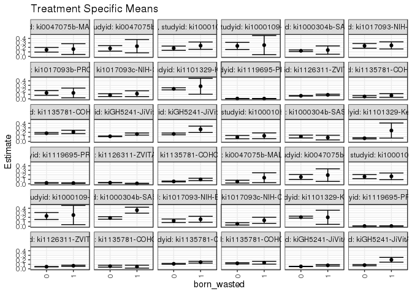

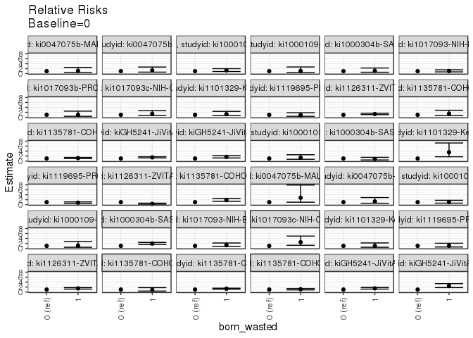

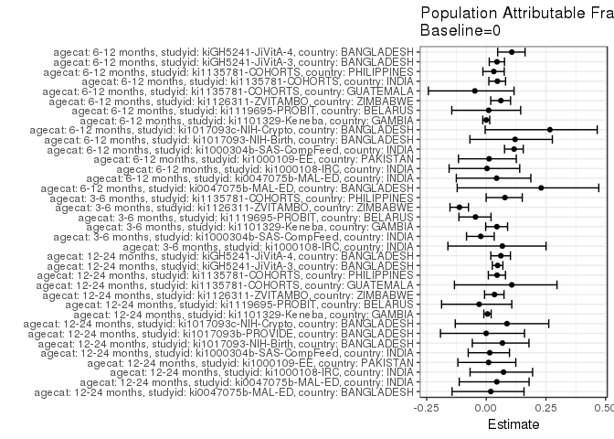

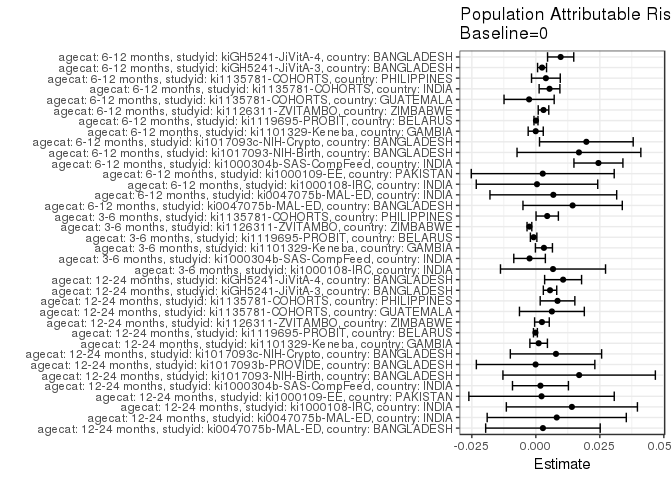

## Results Table

### Parameter: TSM

| agecat | studyid | country | intervention_level | baseline_level | estimate | ci_lower | ci_upper |
| --- | --- | --- | --- | --- | --- | --- | --- |
| 3-6 months | ki1000108-IRC | INDIA | 0 | NA | 0.0932913 | 0.0571141 | 0.1294685 |
| 3-6 months | ki1000108-IRC | INDIA | 1 | NA | 0.1230424 | 0.0590744 | 0.1870105 |
| 3-6 months | ki1000304b-SAS-CompFeed | INDIA | 0 | NA | 0.1067961 | 0.0747761 | 0.1388161 |
| 3-6 months | ki1000304b-SAS-CompFeed | INDIA | 1 | NA | 0.0833333 | 0.0315802 | 0.1350865 |
| 3-6 months | ki1101329-Keneba | GAMBIA | 0 | NA | 0.0682159 | 0.0546818 | 0.0817500 |
| 3-6 months | ki1101329-Keneba | GAMBIA | 1 | NA | 0.2400000 | 0.0725249 | 0.4074751 |
| 3-6 months | ki1119695-PROBIT | BELARUS | 0 | NA | 0.0198673 | 0.0155067 | 0.0242278 |
| 3-6 months | ki1119695-PROBIT | BELARUS | 1 | NA | 0.0156632 | 0.0099015 | 0.0214249 |
| 3-6 months | ki1126311-ZVITAMBO | ZIMBABWE | 0 | NA | 0.0246887 | 0.0210734 | 0.0283040 |
| 3-6 months | ki1126311-ZVITAMBO | ZIMBABWE | 1 | NA | 0.0077952 | 0.0029507 | 0.0126396 |
| 3-6 months | ki1135781-COHORTS | PHILIPPINES | 0 | NA | 0.0525299 | 0.0433449 | 0.0617149 |
| 3-6 months | ki1135781-COHORTS | PHILIPPINES | 1 | NA | 0.0976239 | 0.0716903 | 0.1235576 |
| 6-12 months | ki0047075b-MAL-ED | BANGLADESH | 0 | NA | 0.0481283 | 0.0173824 | 0.0788743 |
| 6-12 months | ki0047075b-MAL-ED | BANGLADESH | 1 | NA | 0.1351351 | 0.0247331 | 0.2455372 |
| 6-12 months | ki0047075b-MAL-ED | INDIA | 0 | NA | 0.1518987 | 0.0957846 | 0.2080129 |
| 6-12 months | ki0047075b-MAL-ED | INDIA | 1 | NA | 0.1935484 | 0.0541033 | 0.3329935 |
| 6-12 months | ki1000108-IRC | INDIA | 0 | NA | 0.1603670 | 0.1149335 | 0.2058004 |
| 6-12 months | ki1000108-IRC | INDIA | 1 | NA | 0.1657436 | 0.0919179 | 0.2395693 |
| 6-12 months | ki1000109-EE | PAKISTAN | 0 | NA | 0.2280702 | 0.1507495 | 0.3053909 |
| 6-12 months | ki1000109-EE | PAKISTAN | 1 | NA | 0.2500000 | 0.0370069 | 0.4629931 |
| 6-12 months | ki1000304b-SAS-CompFeed | INDIA | 0 | NA | 0.1856069 | 0.1574661 | 0.2137477 |
| 6-12 months | ki1000304b-SAS-CompFeed | INDIA | 1 | NA | 0.3577573 | 0.2916946 | 0.4238201 |
| 6-12 months | ki1017093-NIH-Birth | BANGLADESH | 0 | NA | 0.1225729 | 0.0828604 | 0.1622855 |
| 6-12 months | ki1017093-NIH-Birth | BANGLADESH | 1 | NA | 0.1558690 | 0.0904391 | 0.2212989 |
| 6-12 months | ki1017093c-NIH-Crypto | BANGLADESH | 0 | NA | 0.0542465 | 0.0283715 | 0.0801215 |
| 6-12 months | ki1017093c-NIH-Crypto | BANGLADESH | 1 | NA | 0.1338056 | 0.0660875 | 0.2015236 |
| 6-12 months | ki1101329-Keneba | GAMBIA | 0 | NA | 0.2025797 | 0.1808730 | 0.2242864 |
| 6-12 months | ki1101329-Keneba | GAMBIA | 1 | NA | 0.2000000 | 0.0431445 | 0.3568555 |
| 6-12 months | ki1119695-PROBIT | BELARUS | 0 | NA | 0.0053254 | 0.0038182 | 0.0068327 |
| 6-12 months | ki1119695-PROBIT | BELARUS | 1 | NA | 0.0055861 | 0.0016630 | 0.0095092 |
| 6-12 months | ki1126311-ZVITAMBO | ZIMBABWE | 0 | NA | 0.0462083 | 0.0415923 | 0.0508242 |
| 6-12 months | ki1126311-ZVITAMBO | ZIMBABWE | 1 | NA | 0.0673947 | 0.0549926 | 0.0797968 |
| 6-12 months | ki1135781-COHORTS | GUATEMALA | 0 | NA | 0.0572597 | 0.0366513 | 0.0778681 |
| 6-12 months | ki1135781-COHORTS | GUATEMALA | 1 | NA | 0.0470588 | 0.0152017 | 0.0789160 |
| 6-12 months | ki1135781-COHORTS | INDIA | 0 | NA | 0.1101849 | 0.1013265 | 0.1190432 |
| 6-12 months | ki1135781-COHORTS | INDIA | 1 | NA | 0.1460670 | 0.1258458 | 0.1662883 |
| 6-12 months | ki1135781-COHORTS | PHILIPPINES | 0 | NA | 0.1212621 | 0.1077322 | 0.1347920 |
| 6-12 months | ki1135781-COHORTS | PHILIPPINES | 1 | NA | 0.1346508 | 0.1031917 | 0.1661098 |
| 6-12 months | kiGH5241-JiVitA-3 | BANGLADESH | 0 | NA | 0.0519212 | 0.0473109 | 0.0565315 |
| 6-12 months | kiGH5241-JiVitA-3 | BANGLADESH | 1 | NA | 0.0764369 | 0.0606900 | 0.0921838 |
| 6-12 months | kiGH5241-JiVitA-4 | BANGLADESH | 0 | NA | 0.0810909 | 0.0668823 | 0.0952995 |
| 6-12 months | kiGH5241-JiVitA-4 | BANGLADESH | 1 | NA | 0.1999014 | 0.1471741 | 0.2526287 |
| 12-24 months | ki0047075b-MAL-ED | BANGLADESH | 0 | NA | 0.1460674 | 0.0940632 | 0.1980717 |
| 12-24 months | ki0047075b-MAL-ED | BANGLADESH | 1 | NA | 0.1621622 | 0.0431163 | 0.2812080 |
| 12-24 months | ki0047075b-MAL-ED | INDIA | 0 | NA | 0.1776316 | 0.1167046 | 0.2385585 |
| 12-24 months | ki0047075b-MAL-ED | INDIA | 1 | NA | 0.2258065 | 0.0782188 | 0.3733941 |
| 12-24 months | ki1000108-IRC | INDIA | 0 | NA | 0.1812540 | 0.1339297 | 0.2285783 |
| 12-24 months | ki1000108-IRC | INDIA | 1 | NA | 0.2378589 | 0.1566051 | 0.3191128 |
| 12-24 months | ki1000109-EE | PAKISTAN | 0 | NA | 0.2321429 | 0.1536446 | 0.3106411 |
| 12-24 months | ki1000109-EE | PAKISTAN | 1 | NA | 0.2500000 | 0.0369940 | 0.4630060 |
| 12-24 months | ki1000304b-SAS-CompFeed | INDIA | 0 | NA | 0.1240548 | 0.1051819 | 0.1429277 |
| 12-24 months | ki1000304b-SAS-CompFeed | INDIA | 1 | NA | 0.1398893 | 0.0479393 | 0.2318393 |
| 12-24 months | ki1017093-NIH-Birth | BANGLADESH | 0 | NA | 0.2338188 | 0.1808189 | 0.2868187 |
| 12-24 months | ki1017093-NIH-Birth | BANGLADESH | 1 | NA | 0.2437007 | 0.1648823 | 0.3225192 |
| 12-24 months | ki1017093b-PROVIDE | BANGLADESH | 0 | NA | 0.1320755 | 0.0793152 | 0.1848357 |
| 12-24 months | ki1017093b-PROVIDE | BANGLADESH | 1 | NA | 0.1315789 | 0.0238283 | 0.2393296 |
| 12-24 months | ki1017093c-NIH-Crypto | BANGLADESH | 0 | NA | 0.0830450 | 0.0511887 | 0.1149012 |
| 12-24 months | ki1017093c-NIH-Crypto | BANGLADESH | 1 | NA | 0.1145833 | 0.0507846 | 0.1783820 |
| 12-24 months | ki1101329-Keneba | GAMBIA | 0 | NA | 0.2224824 | 0.1996978 | 0.2452671 |
| 12-24 months | ki1101329-Keneba | GAMBIA | 1 | NA | 0.2800000 | 0.1039282 | 0.4560718 |
| 12-24 months | ki1119695-PROBIT | BELARUS | 0 | NA | 0.0053837 | 0.0029471 | 0.0078204 |
| 12-24 months | ki1119695-PROBIT | BELARUS | 1 | NA | 0.0046336 | 0.0009157 | 0.0083515 |
| 12-24 months | ki1126311-ZVITAMBO | ZIMBABWE | 0 | NA | 0.0675583 | 0.0610296 | 0.0740870 |
| 12-24 months | ki1126311-ZVITAMBO | ZIMBABWE | 1 | NA | 0.0892835 | 0.0736474 | 0.1049197 |
| 12-24 months | ki1135781-COHORTS | GUATEMALA | 0 | NA | 0.0524519 | 0.0312246 | 0.0736793 |
| 12-24 months | ki1135781-COHORTS | GUATEMALA | 1 | NA | 0.0754499 | 0.0340416 | 0.1168582 |
| 12-24 months | ki1135781-COHORTS | PHILIPPINES | 0 | NA | 0.1796894 | 0.1635270 | 0.1958517 |
| 12-24 months | ki1135781-COHORTS | PHILIPPINES | 1 | NA | 0.2083539 | 0.1701681 | 0.2465398 |
| 12-24 months | kiGH5241-JiVitA-3 | BANGLADESH | 0 | NA | 0.1114476 | 0.1044339 | 0.1184612 |
| 12-24 months | kiGH5241-JiVitA-3 | BANGLADESH | 1 | NA | 0.1619578 | 0.1384765 | 0.1854391 |
| 12-24 months | kiGH5241-JiVitA-4 | BANGLADESH | 0 | NA | 0.1644673 | 0.1452827 | 0.1836519 |
| 12-24 months | kiGH5241-JiVitA-4 | BANGLADESH | 1 | NA | 0.2670949 | 0.1964733 | 0.3377166 |

### Parameter: E(Y)

| agecat | studyid | country | intervention_level | baseline_level | estimate | ci_lower | ci_upper |
| --- | --- | --- | --- | --- | --- | --- | --- |
| 3-6 months | ki1000108-IRC | INDIA | NA | NA | 0.1000000 | 0.0680648 | 0.1319352 |
| 3-6 months | ki1000304b-SAS-CompFeed | INDIA | NA | NA | 0.1043478 | 0.0742151 | 0.1344806 |
| 3-6 months | ki1101329-Keneba | GAMBIA | NA | NA | 0.0713760 | 0.0576831 | 0.0850689 |
| 3-6 months | ki1119695-PROBIT | BELARUS | NA | NA | 0.0190034 | 0.0148301 | 0.0231768 |
| 3-6 months | ki1126311-ZVITAMBO | ZIMBABWE | NA | NA | 0.0221823 | 0.0190213 | 0.0253432 |
| 3-6 months | ki1135781-COHORTS | PHILIPPINES | NA | NA | 0.0569715 | 0.0481747 | 0.0657684 |
| 6-12 months | ki0047075b-MAL-ED | BANGLADESH | NA | NA | 0.0625000 | 0.0307297 | 0.0942703 |
| 6-12 months | ki0047075b-MAL-ED | INDIA | NA | NA | 0.1587302 | 0.1064946 | 0.2109658 |
| 6-12 months | ki1000108-IRC | INDIA | NA | NA | 0.1608187 | 0.1218275 | 0.1998100 |
| 6-12 months | ki1000109-EE | PAKISTAN | NA | NA | 0.2307692 | 0.1580632 | 0.3034753 |
| 6-12 months | ki1000304b-SAS-CompFeed | INDIA | NA | NA | 0.2100559 | 0.1780909 | 0.2420208 |
| 6-12 months | ki1017093-NIH-Birth | BANGLADESH | NA | NA | 0.1394102 | 0.1042119 | 0.1746085 |
| 6-12 months | ki1017093c-NIH-Crypto | BANGLADESH | NA | NA | 0.0739796 | 0.0480362 | 0.0999229 |
| 6-12 months | ki1101329-Keneba | GAMBIA | NA | NA | 0.2025316 | 0.1810298 | 0.2240335 |
| 6-12 months | ki1119695-PROBIT | BELARUS | NA | NA | 0.0053787 | 0.0037427 | 0.0070147 |
| 6-12 months | ki1126311-ZVITAMBO | ZIMBABWE | NA | NA | 0.0492050 | 0.0448107 | 0.0535993 |
| 6-12 months | ki1135781-COHORTS | GUATEMALA | NA | NA | 0.0546282 | 0.0372644 | 0.0719920 |
| 6-12 months | ki1135781-COHORTS | INDIA | NA | NA | 0.1155310 | 0.1072908 | 0.1237711 |
| 6-12 months | ki1135781-COHORTS | PHILIPPINES | NA | NA | 0.1251903 | 0.1125353 | 0.1378452 |
| 6-12 months | kiGH5241-JiVitA-3 | BANGLADESH | NA | NA | 0.0543537 | 0.0498489 | 0.0588584 |
| 6-12 months | kiGH5241-JiVitA-4 | BANGLADESH | NA | NA | 0.0907828 | 0.0771434 | 0.1044222 |
| 12-24 months | ki0047075b-MAL-ED | BANGLADESH | NA | NA | 0.1488372 | 0.1011498 | 0.1965246 |
| 12-24 months | ki0047075b-MAL-ED | INDIA | NA | NA | 0.1857923 | 0.1292864 | 0.2422983 |
| 12-24 months | ki1000108-IRC | INDIA | NA | NA | 0.1953353 | 0.1533175 | 0.2373530 |
| 12-24 months | ki1000109-EE | PAKISTAN | NA | NA | 0.2343750 | 0.1607017 | 0.3080483 |
| 12-24 months | ki1000304b-SAS-CompFeed | INDIA | NA | NA | 0.1258581 | 0.1080384 | 0.1436778 |
| 12-24 months | ki1017093-NIH-Birth | BANGLADESH | NA | NA | 0.2507375 | 0.2045295 | 0.2969454 |
| 12-24 months | ki1017093b-PROVIDE | BANGLADESH | NA | NA | 0.1319797 | 0.0845949 | 0.1793644 |
| 12-24 months | ki1017093c-NIH-Crypto | BANGLADESH | NA | NA | 0.0909091 | 0.0621557 | 0.1196625 |
| 12-24 months | ki1101329-Keneba | GAMBIA | NA | NA | 0.2235835 | 0.2009782 | 0.2461887 |
| 12-24 months | ki1119695-PROBIT | BELARUS | NA | NA | 0.0052266 | 0.0028868 | 0.0075664 |
| 12-24 months | ki1126311-ZVITAMBO | ZIMBABWE | NA | NA | 0.0699436 | 0.0638514 | 0.0760357 |
| 12-24 months | ki1135781-COHORTS | GUATEMALA | NA | NA | 0.0587219 | 0.0395554 | 0.0778885 |
| 12-24 months | ki1135781-COHORTS | PHILIPPINES | NA | NA | 0.1881615 | 0.1729918 | 0.2033312 |
| 12-24 months | kiGH5241-JiVitA-3 | BANGLADESH | NA | NA | 0.1169922 | 0.1100927 | 0.1238917 |
| 12-24 months | kiGH5241-JiVitA-4 | BANGLADESH | NA | NA | 0.1751174 | 0.1566212 | 0.1936135 |

### Parameter: RR

| agecat | studyid | country | intervention_level | baseline_level | estimate | ci_lower | ci_upper |
| --- | --- | --- | --- | --- | --- | --- | --- |
| 3-6 months | ki1000108-IRC | INDIA | 0 | 0 | 1.0000000 | 1.0000000 | 1.0000000 |
| 3-6 months | ki1000108-IRC | INDIA | 1 | 0 | 1.3189059 | 0.6893045 | 2.5235767 |
| 3-6 months | ki1000304b-SAS-CompFeed | INDIA | 0 | 0 | 1.0000000 | 1.0000000 | 1.0000000 |
| 3-6 months | ki1000304b-SAS-CompFeed | INDIA | 1 | 0 | 0.7803030 | 0.4132212 | 1.4734791 |
| 3-6 months | ki1101329-Keneba | GAMBIA | 0 | 0 | 1.0000000 | 1.0000000 | 1.0000000 |
| 3-6 months | ki1101329-Keneba | GAMBIA | 1 | 0 | 3.5182418 | 1.7031708 | 7.2676357 |
| 3-6 months | ki1119695-PROBIT | BELARUS | 0 | 0 | 1.0000000 | 1.0000000 | 1.0000000 |
| 3-6 months | ki1119695-PROBIT | BELARUS | 1 | 0 | 0.7883926 | 0.5563580 | 1.1171995 |
| 3-6 months | ki1126311-ZVITAMBO | ZIMBABWE | 0 | 0 | 1.0000000 | 1.0000000 | 1.0000000 |
| 3-6 months | ki1126311-ZVITAMBO | ZIMBABWE | 1 | 0 | 0.3157374 | 0.1667488 | 0.5978462 |
| 3-6 months | ki1135781-COHORTS | PHILIPPINES | 0 | 0 | 1.0000000 | 1.0000000 | 1.0000000 |
| 3-6 months | ki1135781-COHORTS | PHILIPPINES | 1 | 0 | 1.8584453 | 1.3522896 | 2.5540526 |
| 6-12 months | ki0047075b-MAL-ED | BANGLADESH | 0 | 0 | 1.0000000 | 1.0000000 | 1.0000000 |
| 6-12 months | ki0047075b-MAL-ED | BANGLADESH | 1 | 0 | 2.8078078 | 0.9953247 | 7.9208169 |
| 6-12 months | ki0047075b-MAL-ED | INDIA | 0 | 0 | 1.0000000 | 1.0000000 | 1.0000000 |
| 6-12 months | ki0047075b-MAL-ED | INDIA | 1 | 0 | 1.2741935 | 0.5670308 | 2.8632821 |
| 6-12 months | ki1000108-IRC | INDIA | 0 | 0 | 1.0000000 | 1.0000000 | 1.0000000 |
| 6-12 months | ki1000108-IRC | INDIA | 1 | 0 | 1.0335271 | 0.6096148 | 1.7522186 |
| 6-12 months | ki1000109-EE | PAKISTAN | 0 | 0 | 1.0000000 | 1.0000000 | 1.0000000 |
| 6-12 months | ki1000109-EE | PAKISTAN | 1 | 0 | 1.0961538 | 0.4381737 | 2.7421848 |
| 6-12 months | ki1000304b-SAS-CompFeed | INDIA | 0 | 0 | 1.0000000 | 1.0000000 | 1.0000000 |
| 6-12 months | ki1000304b-SAS-CompFeed | INDIA | 1 | 0 | 1.9275000 | 1.5562390 | 2.3873302 |
| 6-12 months | ki1017093-NIH-Birth | BANGLADESH | 0 | 0 | 1.0000000 | 1.0000000 | 1.0000000 |
| 6-12 months | ki1017093-NIH-Birth | BANGLADESH | 1 | 0 | 1.2716429 | 0.7489863 | 2.1590189 |
| 6-12 months | ki1017093c-NIH-Crypto | BANGLADESH | 0 | 0 | 1.0000000 | 1.0000000 | 1.0000000 |
| 6-12 months | ki1017093c-NIH-Crypto | BANGLADESH | 1 | 0 | 2.4666213 | 1.2305184 | 4.9444369 |
| 6-12 months | ki1101329-Keneba | GAMBIA | 0 | 0 | 1.0000000 | 1.0000000 | 1.0000000 |
| 6-12 months | ki1101329-Keneba | GAMBIA | 1 | 0 | 0.9872659 | 0.4473655 | 2.1787421 |
| 6-12 months | ki1119695-PROBIT | BELARUS | 0 | 0 | 1.0000000 | 1.0000000 | 1.0000000 |
| 6-12 months | ki1119695-PROBIT | BELARUS | 1 | 0 | 1.0489513 | 0.5347211 | 2.0577061 |
| 6-12 months | ki1126311-ZVITAMBO | ZIMBABWE | 0 | 0 | 1.0000000 | 1.0000000 | 1.0000000 |
| 6-12 months | ki1126311-ZVITAMBO | ZIMBABWE | 1 | 0 | 1.4584982 | 1.1832238 | 1.7978147 |
| 6-12 months | ki1135781-COHORTS | GUATEMALA | 0 | 0 | 1.0000000 | 1.0000000 | 1.0000000 |
| 6-12 months | ki1135781-COHORTS | GUATEMALA | 1 | 0 | 0.8218488 | 0.3817876 | 1.7691393 |
| 6-12 months | ki1135781-COHORTS | INDIA | 0 | 0 | 1.0000000 | 1.0000000 | 1.0000000 |
| 6-12 months | ki1135781-COHORTS | INDIA | 1 | 0 | 1.3256540 | 1.1302668 | 1.5548175 |
| 6-12 months | ki1135781-COHORTS | PHILIPPINES | 0 | 0 | 1.0000000 | 1.0000000 | 1.0000000 |
| 6-12 months | ki1135781-COHORTS | PHILIPPINES | 1 | 0 | 1.1104109 | 0.8575225 | 1.4378775 |
| 6-12 months | kiGH5241-JiVitA-3 | BANGLADESH | 0 | 0 | 1.0000000 | 1.0000000 | 1.0000000 |
| 6-12 months | kiGH5241-JiVitA-3 | BANGLADESH | 1 | 0 | 1.4721711 | 1.1773650 | 1.8407951 |
| 6-12 months | kiGH5241-JiVitA-4 | BANGLADESH | 0 | 0 | 1.0000000 | 1.0000000 | 1.0000000 |
| 6-12 months | kiGH5241-JiVitA-4 | BANGLADESH | 1 | 0 | 2.4651533 | 1.7888714 | 3.3971032 |
| 12-24 months | ki0047075b-MAL-ED | BANGLADESH | 0 | 0 | 1.0000000 | 1.0000000 | 1.0000000 |
| 12-24 months | ki0047075b-MAL-ED | BANGLADESH | 1 | 0 | 1.1101871 | 0.4909733 | 2.5103514 |
| 12-24 months | ki0047075b-MAL-ED | INDIA | 0 | 0 | 1.0000000 | 1.0000000 | 1.0000000 |
| 12-24 months | ki0047075b-MAL-ED | INDIA | 1 | 0 | 1.2712067 | 0.6076429 | 2.6594016 |
| 12-24 months | ki1000108-IRC | INDIA | 0 | 0 | 1.0000000 | 1.0000000 | 1.0000000 |
| 12-24 months | ki1000108-IRC | INDIA | 1 | 0 | 1.3122960 | 0.8602257 | 2.0019407 |
| 12-24 months | ki1000109-EE | PAKISTAN | 0 | 0 | 1.0000000 | 1.0000000 | 1.0000000 |
| 12-24 months | ki1000109-EE | PAKISTAN | 1 | 0 | 1.0769231 | 0.4306049 | 2.6933350 |
| 12-24 months | ki1000304b-SAS-CompFeed | INDIA | 0 | 0 | 1.0000000 | 1.0000000 | 1.0000000 |
| 12-24 months | ki1000304b-SAS-CompFeed | INDIA | 1 | 0 | 1.1276413 | 0.5593936 | 2.2731306 |
| 12-24 months | ki1017093-NIH-Birth | BANGLADESH | 0 | 0 | 1.0000000 | 1.0000000 | 1.0000000 |
| 12-24 months | ki1017093-NIH-Birth | BANGLADESH | 1 | 0 | 1.0422631 | 0.7021968 | 1.5470197 |
| 12-24 months | ki1017093b-PROVIDE | BANGLADESH | 0 | 0 | 1.0000000 | 1.0000000 | 1.0000000 |
| 12-24 months | ki1017093b-PROVIDE | BANGLADESH | 1 | 0 | 0.9962406 | 0.4005529 | 2.4778132 |
| 12-24 months | ki1017093c-NIH-Crypto | BANGLADESH | 0 | 0 | 1.0000000 | 1.0000000 | 1.0000000 |
| 12-24 months | ki1017093c-NIH-Crypto | BANGLADESH | 1 | 0 | 1.3797743 | 0.7017210 | 2.7130113 |
| 12-24 months | ki1101329-Keneba | GAMBIA | 0 | 0 | 1.0000000 | 1.0000000 | 1.0000000 |
| 12-24 months | ki1101329-Keneba | GAMBIA | 1 | 0 | 1.2585263 | 0.6655304 | 2.3798891 |
| 12-24 months | ki1119695-PROBIT | BELARUS | 0 | 0 | 1.0000000 | 1.0000000 | 1.0000000 |
| 12-24 months | ki1119695-PROBIT | BELARUS | 1 | 0 | 0.8606650 | 0.4020555 | 1.8423931 |
| 12-24 months | ki1126311-ZVITAMBO | ZIMBABWE | 0 | 0 | 1.0000000 | 1.0000000 | 1.0000000 |
| 12-24 months | ki1126311-ZVITAMBO | ZIMBABWE | 1 | 0 | 1.3215774 | 1.0821918 | 1.6139161 |
| 12-24 months | ki1135781-COHORTS | GUATEMALA | 0 | 0 | 1.0000000 | 1.0000000 | 1.0000000 |
| 12-24 months | ki1135781-COHORTS | GUATEMALA | 1 | 0 | 1.4384571 | 0.7279980 | 2.8422588 |
| 12-24 months | ki1135781-COHORTS | PHILIPPINES | 0 | 0 | 1.0000000 | 1.0000000 | 1.0000000 |
| 12-24 months | ki1135781-COHORTS | PHILIPPINES | 1 | 0 | 1.1595227 | 0.9456579 | 1.4217539 |
| 12-24 months | kiGH5241-JiVitA-3 | BANGLADESH | 0 | 0 | 1.0000000 | 1.0000000 | 1.0000000 |
| 12-24 months | kiGH5241-JiVitA-3 | BANGLADESH | 1 | 0 | 1.4532192 | 1.2433000 | 1.6985811 |
| 12-24 months | kiGH5241-JiVitA-4 | BANGLADESH | 0 | 0 | 1.0000000 | 1.0000000 | 1.0000000 |
| 12-24 months | kiGH5241-JiVitA-4 | BANGLADESH | 1 | 0 | 1.6240005 | 1.2125751 | 2.1750222 |

### Parameter: PAR

| agecat | studyid | country | intervention_level | baseline_level | estimate | ci_lower | ci_upper |
| --- | --- | --- | --- | --- | --- | --- | --- |
| 3-6 months | ki1000108-IRC | INDIA | 0 | NA | 0.0067087 | -0.0138132 | 0.0272306 |
| 3-6 months | ki1000304b-SAS-CompFeed | INDIA | 0 | NA | -0.0024483 | -0.0086158 | 0.0037192 |
| 3-6 months | ki1101329-Keneba | GAMBIA | 0 | NA | 0.0031601 | -0.0001657 | 0.0064859 |
| 3-6 months | ki1119695-PROBIT | BELARUS | 0 | NA | -0.0008638 | -0.0021275 | 0.0003998 |
| 3-6 months | ki1126311-ZVITAMBO | ZIMBABWE | 0 | NA | -0.0025065 | -0.0034350 | -0.0015779 |
| 3-6 months | ki1135781-COHORTS | PHILIPPINES | 0 | NA | 0.0044416 | 0.0000786 | 0.0088047 |
| 6-12 months | ki0047075b-MAL-ED | BANGLADESH | 0 | NA | 0.0143717 | -0.0050275 | 0.0337708 |
| 6-12 months | ki0047075b-MAL-ED | INDIA | 0 | NA | 0.0068314 | -0.0179213 | 0.0315842 |
| 6-12 months | ki1000108-IRC | INDIA | 0 | NA | 0.0004518 | -0.0232727 | 0.0241762 |
| 6-12 months | ki1000109-EE | PAKISTAN | 0 | NA | 0.0026991 | -0.0252171 | 0.0306152 |
| 6-12 months | ki1000304b-SAS-CompFeed | INDIA | 0 | NA | 0.0244489 | 0.0148820 | 0.0340159 |
| 6-12 months | ki1017093-NIH-Birth | BANGLADESH | 0 | NA | 0.0168373 | -0.0073436 | 0.0410181 |
| 6-12 months | ki1017093c-NIH-Crypto | BANGLADESH | 0 | NA | 0.0197331 | 0.0014363 | 0.0380299 |
| 6-12 months | ki1101329-Keneba | GAMBIA | 0 | NA | -0.0000480 | -0.0029958 | 0.0028997 |
| 6-12 months | ki1119695-PROBIT | BELARUS | 0 | NA | 0.0000533 | -0.0007272 | 0.0008337 |
| 6-12 months | ki1126311-ZVITAMBO | ZIMBABWE | 0 | NA | 0.0029967 | 0.0009362 | 0.0050572 |
| 6-12 months | ki1135781-COHORTS | GUATEMALA | 0 | NA | -0.0026315 | -0.0124252 | 0.0071622 |
| 6-12 months | ki1135781-COHORTS | INDIA | 0 | NA | 0.0053461 | 0.0012846 | 0.0094076 |
| 6-12 months | ki1135781-COHORTS | PHILIPPINES | 0 | NA | 0.0039281 | -0.0016832 | 0.0095395 |
| 6-12 months | kiGH5241-JiVitA-3 | BANGLADESH | 0 | NA | 0.0024325 | 0.0006801 | 0.0041848 |
| 6-12 months | kiGH5241-JiVitA-4 | BANGLADESH | 0 | NA | 0.0096919 | 0.0045775 | 0.0148063 |
| 12-24 months | ki0047075b-MAL-ED | BANGLADESH | 0 | NA | 0.0027698 | -0.0196015 | 0.0251410 |
| 12-24 months | ki0047075b-MAL-ED | INDIA | 0 | NA | 0.0081608 | -0.0190141 | 0.0353356 |
| 12-24 months | ki1000108-IRC | INDIA | 0 | NA | 0.0140812 | -0.0115227 | 0.0396852 |
| 12-24 months | ki1000109-EE | PAKISTAN | 0 | NA | 0.0022321 | -0.0261627 | 0.0306270 |
| 12-24 months | ki1000304b-SAS-CompFeed | INDIA | 0 | NA | 0.0018033 | -0.0091218 | 0.0127285 |
| 12-24 months | ki1017093-NIH-Birth | BANGLADESH | 0 | NA | 0.0169186 | -0.0128548 | 0.0466921 |
| 12-24 months | ki1017093b-PROVIDE | BANGLADESH | 0 | NA | -0.0000958 | -0.0232380 | 0.0230465 |
| 12-24 months | ki1017093c-NIH-Crypto | BANGLADESH | 0 | NA | 0.0078641 | -0.0099693 | 0.0256976 |
| 12-24 months | ki1101329-Keneba | GAMBIA | 0 | NA | 0.0011010 | -0.0023243 | 0.0045264 |
| 12-24 months | ki1119695-PROBIT | BELARUS | 0 | NA | -0.0001571 | -0.0009180 | 0.0006038 |
| 12-24 months | ki1126311-ZVITAMBO | ZIMBABWE | 0 | NA | 0.0023853 | -0.0004766 | 0.0052471 |
| 12-24 months | ki1135781-COHORTS | GUATEMALA | 0 | NA | 0.0062700 | -0.0063980 | 0.0189379 |
| 12-24 months | ki1135781-COHORTS | PHILIPPINES | 0 | NA | 0.0084721 | 0.0017040 | 0.0152403 |
| 12-24 months | kiGH5241-JiVitA-3 | BANGLADESH | 0 | NA | 0.0055446 | 0.0029278 | 0.0081615 |
| 12-24 months | kiGH5241-JiVitA-4 | BANGLADESH | 0 | NA | 0.0106501 | 0.0034315 | 0.0178687 |

### Parameter: PAF

| agecat | studyid | country | intervention_level | baseline_level | estimate | ci_lower | ci_upper |
| --- | --- | --- | --- | --- | --- | --- | --- |
| 3-6 months | ki1000108-IRC | INDIA | 0 | NA | 0.0670870 | -0.1611515 | 0.2504624 |
| 3-6 months | ki1000304b-SAS-CompFeed | INDIA | 0 | NA | -0.0234628 | -0.0831795 | 0.0329617 |
| 3-6 months | ki1101329-Keneba | GAMBIA | 0 | NA | 0.0442743 | -0.0027778 | 0.0891185 |
| 3-6 months | ki1119695-PROBIT | BELARUS | 0 | NA | -0.0454560 | -0.1149060 | 0.0196678 |
| 3-6 months | ki1126311-ZVITAMBO | ZIMBABWE | 0 | NA | -0.1129940 | -0.1524401 | -0.0748982 |
| 3-6 months | ki1135781-COHORTS | PHILIPPINES | 0 | NA | 0.0779622 | -0.0008584 | 0.1505754 |
| 6-12 months | ki0047075b-MAL-ED | BANGLADESH | 0 | NA | 0.2299465 | -0.1221620 | 0.4715715 |
| 6-12 months | ki0047075b-MAL-ED | INDIA | 0 | NA | 0.0430380 | -0.1258451 | 0.1865877 |
| 6-12 months | ki1000108-IRC | INDIA | 0 | NA | 0.0028091 | -0.1561783 | 0.1399340 |
| 6-12 months | ki1000109-EE | PAKISTAN | 0 | NA | 0.0116959 | -0.1169631 | 0.1255351 |
| 6-12 months | ki1000304b-SAS-CompFeed | INDIA | 0 | NA | 0.1163926 | 0.0762616 | 0.1547801 |
| 6-12 months | ki1017093-NIH-Birth | BANGLADESH | 0 | NA | 0.1207749 | -0.0688450 | 0.2767550 |
| 6-12 months | ki1017093c-NIH-Crypto | BANGLADESH | 0 | NA | 0.2667371 | -0.0049939 | 0.4649972 |
| 6-12 months | ki1101329-Keneba | GAMBIA | 0 | NA | -0.0002371 | -0.0148981 | 0.0142121 |
| 6-12 months | ki1119695-PROBIT | BELARUS | 0 | NA | 0.0099003 | -0.1450281 | 0.1438661 |
| 6-12 months | ki1126311-ZVITAMBO | ZIMBABWE | 0 | NA | 0.0609024 | 0.0184173 | 0.1015486 |
| 6-12 months | ki1135781-COHORTS | GUATEMALA | 0 | NA | -0.0481709 | -0.2430114 | 0.1161286 |
| 6-12 months | ki1135781-COHORTS | INDIA | 0 | NA | 0.0462741 | 0.0106059 | 0.0806563 |
| 6-12 months | ki1135781-COHORTS | PHILIPPINES | 0 | NA | 0.0313774 | -0.0144152 | 0.0751029 |
| 6-12 months | kiGH5241-JiVitA-3 | BANGLADESH | 0 | NA | 0.0447526 | 0.0122559 | 0.0761802 |
| 6-12 months | kiGH5241-JiVitA-4 | BANGLADESH | 0 | NA | 0.1067593 | 0.0474483 | 0.1623773 |
| 12-24 months | ki0047075b-MAL-ED | BANGLADESH | 0 | NA | 0.0186096 | -0.1437279 | 0.1579053 |
| 12-24 months | ki0047075b-MAL-ED | INDIA | 0 | NA | 0.0439241 | -0.1137207 | 0.1792547 |
| 12-24 months | ki1000108-IRC | INDIA | 0 | NA | 0.0720876 | -0.0682487 | 0.1939878 |
| 12-24 months | ki1000109-EE | PAKISTAN | 0 | NA | 0.0095238 | -0.1193320 | 0.1235459 |
| 12-24 months | ki1000304b-SAS-CompFeed | INDIA | 0 | NA | 0.0143283 | -0.0759797 | 0.0970566 |
| 12-24 months | ki1017093-NIH-Birth | BANGLADESH | 0 | NA | 0.0674755 | -0.0588073 | 0.1786966 |
| 12-24 months | ki1017093b-PROVIDE | BANGLADESH | 0 | NA | -0.0007257 | -0.1923729 | 0.1601185 |
| 12-24 months | ki1017093c-NIH-Crypto | BANGLADESH | 0 | NA | 0.0865052 | -0.1303789 | 0.2617761 |
| 12-24 months | ki1101329-Keneba | GAMBIA | 0 | NA | 0.0049244 | -0.0105108 | 0.0201239 |
| 12-24 months | ki1119695-PROBIT | BELARUS | 0 | NA | -0.0300572 | -0.1876559 | 0.1066287 |
| 12-24 months | ki1126311-ZVITAMBO | ZIMBABWE | 0 | NA | 0.0341027 | -0.0075667 | 0.0740488 |
| 12-24 months | ki1135781-COHORTS | GUATEMALA | 0 | NA | 0.1067742 | -0.1337447 | 0.2962681 |
| 12-24 months | ki1135781-COHORTS | PHILIPPINES | 0 | NA | 0.0450258 | 0.0084498 | 0.0802526 |
| 12-24 months | kiGH5241-JiVitA-3 | BANGLADESH | 0 | NA | 0.0473931 | 0.0249999 | 0.0692720 |
| 12-24 months | kiGH5241-JiVitA-4 | BANGLADESH | 0 | NA | 0.0608169 | 0.0188124 | 0.1010232 |